# Processing Results from DADA2 to make plots, do some statistics

Liz Suter

April 14, 2021

[Link](https://lizsuter.github.io/files/Ecol_analysis.nb.html) to notebook

[Link](https://github.com/lizsuter/SCM_eDNA) to github repo.

# Table of Contents

- Load packages
- Import and prepare the data from eDNA
  - Import metadata
  - Import DADA2 results
- QC and filtering eDNA dataset
  - Rarefaction curves
  - Filtering
  - Check sequencing effort
- Abundance plots eDNA
  - Abundance at family level
  - Bubble plots
- Import and prepare the data from trawls
  - Import Trawl Master sheet
  - Convert to count table
- Abundance plots Trawls
- Abundance Plots Compare Trawl and eDNA
- Exploratory Analyses
  - Ordinations on eDNA
    - PCA
    - PCoA Jaccard
    - PCoA Bray Curtis
    - NMDS
    - eDNA Ordinations Summary

# Load packages

```r
library(tidyverse)
library(readxl)
library(phyloseq)
#library(dada2)
library(Biostrings)
#library(DECIPHER)
library(phangorn)
library(readr)
library(seqinr)
library(decontam)
library(ape)
library(vegan)
#library(philr)
library(RColorBrewer)
library(microbiome)
#library(DESeq2)
library(compositions);
library(cowplot)
library(plotly)
library(htmlwidgets)
library(withr)
library(lubridate)
```

# Import and prepare the data from eDNA

## Import metadata

```r
metadata <- read_csv("sample_data.csv")
```

## Import DADA2 results

Import count table and taxonomy file. I slightly modified otutable.csv in Excel to otutable_mod.csv to remove the quotes around seq names and put NA placehoder as first col name (which was above row names)

```r
# Import Count table. Skip first row of tsv file, which is just some text
count_table <- read_table2("results/otutable_mod.csv")
colnames(count_table)[1] <- "SampleID"

# Import taxonomy of ASVs
taxonomy <- read_csv(file="results/tax_sequences_blast_taxonomy.csv")
# remove first col of sequential numbers
taxonomy[,1] <- NULL
# filter out sequences with low PID (recommended by Sara)
taxonomy <- filter(taxonomy, PID > 92)

# remove BLAST metadata and just retain taxonomy (necessary for further processing below)
drop.cols <- c(colnames(taxonomy)[2:9],'RefSeq_Tax_ID_1')
taxonomy <-  select(taxonomy, -one_of(drop.cols))


# And import the Common names, as curated by Sara. Join to taxonomy
commonnames <- read_excel("Trawls MASTER 2020 _mod_ES.xlsx",7)
commonnames
```

| ASV_ID | CommonName |
| --- | --- |
| Seq_1 | Atlantic silverside |
| Seq_2 | Atlantic menhaden |
| Seq_3 | Bay anchovy |
| Seq_4 | Bluefish |
| Seq_5 | Grey snapper |
| Seq_6 | Summer flounder |
| Seq_7 | Hickory shad |
| Seq_8 | Bay anchovy |
| Seq_9 | Seaboard goby |
| Seq_10 | Windowpane flounder |

[output cut: 371 more lines]

```r
taxonomy <- left_join(taxonomy, commonnames, by = "ASV_ID")
taxonomy
```

| ASV_ID | superkingdom | phylum | class | order | family | genus | species | CommonName |
| --- | --- | --- | --- | --- | --- | --- | --- | --- |
| Seq_1 | Eukaryota | Chordata | Actinopteri | Atheriniformes | Atherinopsidae | Menidia | Menidia menidia | Atlantic silverside |
| Seq_2 | Eukaryota | Chordata | Actinopteri | Clupeiformes | Clupeidae | Brevoortia | Brevoortia tyrannus | Atlantic menhaden |
| Seq_3 | Eukaryota | Chordata | Actinopteri | Clupeiformes | Engraulidae | Engraulis | Engraulis encrasicolus | Bay anchovy |
| Seq_4 | Eukaryota | Chordata | Actinopteri | Scombriformes | Pomatomidae | Pomatomus | Pomatomus saltatrix | Bluefish |
| Seq_5 | Eukaryota | Chordata | Actinopteri | Lutjaniformes | Lutjanidae | Lutjanus | Lutjanus griseus | Grey snapper |
| Seq_6 | Eukaryota | Chordata | Actinopteri | Pleuronectiformes | Paralichthyidae | Paralichthys | Paralichthys dentatus | Summer flounder |
| Seq_7 | Eukaryota | Chordata | Actinopteri | Clupeiformes | Clupeidae | Alosa | Alosa mediocris | Hickory shad |
| Seq_8 | Eukaryota | Chordata | Actinopteri | Clupeiformes | Engraulidae | Engraulis | Engraulis encrasicolus | Bay anchovy |
| Seq_9 | Eukaryota | Chordata | Actinopteri | Gobiiformes | Gobiidae | Gobiosoma | Gobiosoma ginsburgi | Seaboard goby |
| Seq_10 | Eukaryota | Chordata | Actinopteri | Pleuronectiformes | Scophthalmidae | Scophthalmus | Scophthalmus aquosus | Windowpane flounder |

[output cut: 369 more lines]

```r
NA
```

Filtering removed seqs 110, 332 (Gobiosoma ginsburgi and Belone belone) *Note for Sara* should we consider setting this at 97% which is more robust and still leaves 334 unique ASVs (rather than 379 with the 92% cutoff in the settings above)

Preview datasets

```r
count_table
```

| SampleID | Seq_1 | Seq_2 | Seq_3 | Seq_4 | Seq_5 | Seq_6 | Seq_7 | Seq_8 | Seq_9 | Seq_10 | Seq_11 | Seq_12 | Seq_13 | Seq_14 | Seq_15 | Seq_16 | Seq_17 | Seq_18 | Seq_19 | Seq_20 | Seq_21 | Seq_22 | Seq_23 | Seq_24 | Seq_25 | Seq_26 | Seq_27 | Seq_28 | Seq_29 | … |
| --- | --- | --- | --- | --- | --- | --- | --- | --- | --- | --- | --- | --- | --- | --- | --- | --- | --- | --- | --- | --- | --- | --- | --- | --- | --- | --- | --- | --- | --- | --- |
| T1PosCon_S11 | 0 | 0 | 0 | 0 | 95147 | 0 | 0 | 0 | 0 | 0 | 0 | 0 | 0 | 0 | 0 | 0 | 0 | 0 | 0 | 0 | 0 | 0 | 0 | 0 | 0 | 0 | 0 | 0 | 0 | … |
| T1S10_S9 | 26533 | 0 | 5777 | 0 | 0 | 0 | 0 | 0 | 0 | 0 | 0 | 0 | 0 | 0 | 0 | 0 | 0 | 0 | 0 | 0 | 0 | 0 | 0 | 486 | 0 | 0 | 0 | 209 | 0 | … |
| T1S11_S10 | 28402 | 8652 | 32846 | 0 | 0 | 2252 | 0 | 138 | 0 | 0 | 0 | 13683 | 0 | 378 | 0 | 0 | 0 | 0 | 0 | 0 | 0 | 0 | 0 | 511 | 0 | 209 | 0 | 1185 | 0 | … |
| T1S1_S1 | 12954 | 0 | 0 | 0 | 0 | 0 | 52437 | 0 | 0 | 0 | 0 | 0 | 0 | 0 | 0 | 0 | 0 | 0 | 0 | 0 | 9602 | 0 | 0 | 241 | 0 | 0 | 0 | 0 | 0 | … |
| T1S2_S2 | 2384 | 0 | 107 | 0 | 0 | 0 | 0 | 0 | 0 | 0 | 0 | 0 | 0 | 0 | 0 | 0 | 36 | 0 | 0 | 0 | 42 | 0 | 0 | 15 | 0 | 0 | 0 | 6 | 0 | … |
| T1S3_S3 | 81146 | 0 | 0 | 0 | 0 | 0 | 0 | 0 | 0 | 0 | 0 | 0 | 0 | 0 | 0 | 0 | 0 | 0 | 0 | 0 | 0 | 0 | 0 | 1652 | 0 | 0 | 0 | 0 | 0 | … |
| T1S5_S4 | 13243 | 0 | 0 | 2096 | 0 | 0 | 0 | 0 | 0 | 0 | 0 | 0 | 0 | 0 | 0 | 0 | 5569 | 0 | 12186 | 0 | 0 | 12966 | 0 | 47 | 0 | 0 | 0 | 0 | 0 | … |
| T1S6_S5 | 0 | 397 | 0 | 0 | 0 | 0 | 0 | 0 | 0 | 48612 | 0 | 0 | 0 | 15 | 0 | 0 | 0 | 0 | 0 | 0 | 0 | 0 | 0 | 0 | 0 | 7 | 0 | 0 | 0 | … |
| T1S7_S6 | 0 | 0 | 0 | 0 | 0 | 0 | 0 | 0 | 0 | 0 | 0 | 0 | 0 | 0 | 0 | 0 | 0 | 0 | 0 | 0 | 0 | 0 | 0 | 0 | 0 | 0 | 0 | 0 | 0 | … |
| T1S8_S7 | 0 | 0 | 0 | 0 | 0 | 0 | 0 | 0 | 0 | 0 | 0 | 0 | 0 | 0 | 0 | 0 | 0 | 0 | 0 | 0 | 0 | 0 | 0 | 0 | 0 | 0 | 0 | 0 | 0 | … |

[output cut: 45 more lines]

```r
taxonomy
```

| ASV_ID | superkingdom | phylum | class | order | family | genus | species | CommonName |
| --- | --- | --- | --- | --- | --- | --- | --- | --- |
| Seq_1 | Eukaryota | Chordata | Actinopteri | Atheriniformes | Atherinopsidae | Menidia | Menidia menidia | Atlantic silverside |
| Seq_2 | Eukaryota | Chordata | Actinopteri | Clupeiformes | Clupeidae | Brevoortia | Brevoortia tyrannus | Atlantic menhaden |
| Seq_3 | Eukaryota | Chordata | Actinopteri | Clupeiformes | Engraulidae | Engraulis | Engraulis encrasicolus | Bay anchovy |
| Seq_4 | Eukaryota | Chordata | Actinopteri | Scombriformes | Pomatomidae | Pomatomus | Pomatomus saltatrix | Bluefish |
| Seq_5 | Eukaryota | Chordata | Actinopteri | Lutjaniformes | Lutjanidae | Lutjanus | Lutjanus griseus | Grey snapper |
| Seq_6 | Eukaryota | Chordata | Actinopteri | Pleuronectiformes | Paralichthyidae | Paralichthys | Paralichthys dentatus | Summer flounder |
| Seq_7 | Eukaryota | Chordata | Actinopteri | Clupeiformes | Clupeidae | Alosa | Alosa mediocris | Hickory shad |
| Seq_8 | Eukaryota | Chordata | Actinopteri | Clupeiformes | Engraulidae | Engraulis | Engraulis encrasicolus | Bay anchovy |
| Seq_9 | Eukaryota | Chordata | Actinopteri | Gobiiformes | Gobiidae | Gobiosoma | Gobiosoma ginsburgi | Seaboard goby |
| Seq_10 | Eukaryota | Chordata | Actinopteri | Pleuronectiformes | Scophthalmidae | Scophthalmus | Scophthalmus aquosus | Windowpane flounder |

[output cut: 369 more lines]

```r
metadata
```

| SampleID | Year.Trawl# | Datecode | Date | Month | Year | Bayside | Station |
| --- | --- | --- | --- | --- | --- | --- | --- |
| T1PosCon | 2020.T1 | 20200707 | 7/7/20 | 7 | 2020 | NA | POS CON |
| T1S1 | 2020.T1 | 20200707 | 7/7/20 | 7 | 2020 | WEST | PINE NECK |
| T1S2 | 2020.T1 | 20200707 | 7/7/20 | 7 | 2020 | WEST | WEST MID BAY |
| T1S3 | 2020.T1 | 20200707 | 7/7/20 | 7 | 2020 | WEST | DUNE ROAD |
| T1S5 | 2020.T1 | 20200707 | 7/7/20 | 7 | 2020 | EAST | PONQUOGUE BRIDGE |
| T1S6 | 2020.T1 | 20200707 | 7/7/20 | 7 | 2020 | EAST | INLET |
| T1S7 | 2020.T1 | 20200707 | 7/7/20 | 7 | 2020 | EAST | CORMORANT POINT |
| T1S8 | 2020.T1 | 20200707 | 7/7/20 | 7 | 2020 | EAST | SHINNECOCK HILLS |
| T1S9 | 2020.T1 | 20200707 | 7/7/20 | 7 | 2020 | EAST | EAST MID BAY |
| T1S10 | 2020.T1 | 20200707 | 7/7/20 | 7 | 2020 | EAST | SOUTH GRASS |

[output cut: 45 more lines]

## Make phyloseq object

I want to use the phyloseq package for some plotting/ statistics, which first requires making phyloseq objects out of each of input data tables-

```r
count_table_matrix <- as.matrix(count_table[,2:392]) # convert count table to matrix, leaving out character column of sample ID
rownames(count_table_matrix) <- count_table$SampleID # add back in Sample IDs as row names
ASV =   otu_table(count_table_matrix, taxa_are_rows =  FALSE)

taxonomy_matrix <- as.matrix(taxonomy[,2:9])
rownames(taxonomy_matrix) <- taxonomy$ASV_ID
TAX =   tax_table(taxonomy_matrix)

META    =   sample_data(data.frame(metadata, row.names = metadata$`SampleID`))
```

First check that the inputs are in compatible formats by checking for ASV names with the phyloseq function, taxa_names

```r
head(taxa_names(TAX))
```

```
[1] "Seq_1" "Seq_2" "Seq_3" "Seq_4" "Seq_5" "Seq_6"
```

```r
head(taxa_names(ASV))
```

```
[1] "Seq_1" "Seq_2" "Seq_3" "Seq_4" "Seq_5" "Seq_6"
```

And check sample names were also detected

```r
# Modify taxa names in ASV, which are formatted with the sample ID, underscor, fastq ID. Don't need this fastq ID anymore and want it to match the sample names from metadata
sample_names(ASV) <-  sample_names(ASV) %>%
  str_replace_all(pattern = "_S[:digit:]+",replacement = "")


head(sample_names(ASV))
```

```
[1] "T1PosCon" "T1S10"    "T1S11"    "T1S1"     "T1S2"     "T1S3"
```

```r
head(sample_names(META))
```

```
[1] "T1PosCon" "T1S1"     "T1S2"     "T1S3"     "T1S5"     "T1S6"
```

And make the phyloseq object

```r
ps <- phyloseq(ASV, TAX,    META)
```

# QC and filtering eDNA dataset

## Rarefaction curves

```r
rarecurve(otu_table(ps), step=50, cex=0.5)
```

```
empty rows removed
```

```r
# save as .eps
setEPS()
postscript("Figures/rarefaction.eps")
```

```r
rarecurve(otu_table(ps), step=50, cex=0.5)
```

```
empty rows removed
```

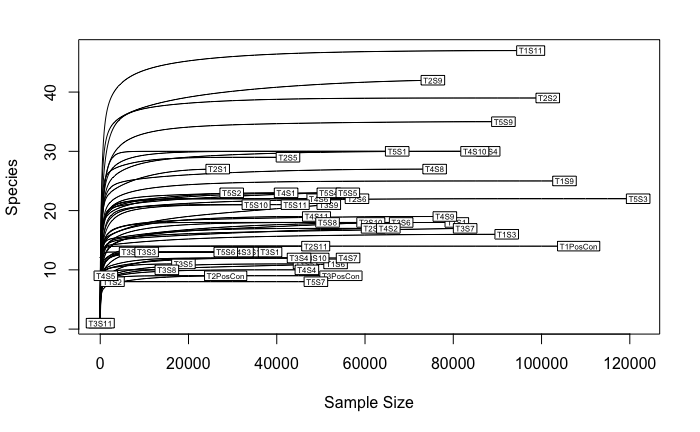

```r
dev.off()
```

Most samples look like they were sampled to completion. Be weary of T3S11, T1S2, and maybe T4S5

## Filtering

Check some features of the phyloseq object

```r
rank_names(ps)
```

```
[1] "superkingdom" "phylum"       "class"        "order"        "family"       "genus"        "species"
[8] "CommonName"
```

```r
unique(tax_table(ps)[, "superkingdom"])
```

```
Taxonomy Table:     [2 taxa by 1 taxonomic ranks]:
        superkingdom
Seq_1   "Eukaryota"
Seq_377 NA
```

```r
unique(tax_table(ps)[, "phylum"])
```

```
Taxonomy Table:     [3 taxa by 1 taxonomic ranks]:
        phylum
Seq_1   "Chordata"
Seq_368 "Arthropoda"
Seq_377 NA
```

```r
unique(tax_table(ps)[, "class"])
```

```
Taxonomy Table:     [5 taxa by 1 taxonomic ranks]:
        class
Seq_1   "Actinopteri"
Seq_63  "Mammalia"
Seq_362 "Chondrichthyes"
Seq_368 "Insecta"
Seq_377 NA
```

There are some ASVs with `NA` as superkingdom, phylum, or class annotation- delete these.

```r
ps <- subset_taxa(ps, !is.na(superkingdom) & !is.na(phylum) & !is.na(class))

unique(tax_table(ps)[, "superkingdom"])
```

```
Taxonomy Table:     [1 taxa by 1 taxonomic ranks]:
      superkingdom
Seq_1 "Eukaryota"
```

```r
unique(tax_table(ps)[, "phylum"])
```

```
Taxonomy Table:     [2 taxa by 1 taxonomic ranks]:
        phylum
Seq_1   "Chordata"
Seq_368 "Arthropoda"
```

```r
unique(tax_table(ps)[, "class"])
```

```
Taxonomy Table:     [4 taxa by 1 taxonomic ranks]:
        class
Seq_1   "Actinopteri"
Seq_63  "Mammalia"
Seq_362 "Chondrichthyes"
Seq_368 "Insecta"
```

```r
nrow(tax_table(ps)) # number of ASVs left
```

```
[1] 378
```

378 ASVs still remain…

Also check class Mammalia, to see if contamination or real:

```r
tax_table(subset_taxa(ps, class == 'Mammalia'))
```

```
Taxonomy Table:     [8 taxa by 8 taxonomic ranks]:
        superkingdom phylum     class      order          family      genus   species        CommonName
Seq_63  "Eukaryota"  "Chordata" "Mammalia" "Primates"     "Hominidae" "Homo"  "Homo sapiens" "Human"
Seq_88  "Eukaryota"  "Chordata" "Mammalia" "Artiodactyla" "Suidae"    "Sus"   "Sus scrofa"   "Wild boar"
Seq_157 "Eukaryota"  "Chordata" "Mammalia" "Primates"     "Hominidae" "Homo"  "Homo sapiens" "Human"
Seq_343 "Eukaryota"  "Chordata" "Mammalia" "Carnivora"    "Felidae"   "Felis" "Felis catus"  "Cat"
Seq_369 "Eukaryota"  "Chordata" "Mammalia" "Artiodactyla" "Bovidae"   "Bos"   "Bos taurus"   "Cattle"
Seq_378 "Eukaryota"  "Chordata" "Mammalia" "Primates"     "Hominidae" "Homo"  "Homo sapiens" "Human"
Seq_383 "Eukaryota"  "Chordata" "Mammalia" "Primates"     "Hominidae" "Homo"  "Homo sapiens" "Human"
Seq_389 "Eukaryota"  "Chordata" "Mammalia" "Primates"     "Hominidae" "Homo"  "Homo sapiens" "Human"
```

These are human, wild boar, cat (…cat lady), and cattle. All are contamination so delete all Mammalia

```r
ps <- subset_taxa(ps, !class == 'Mammalia')
unique(tax_table(ps)[, "class"])
```

```
Taxonomy Table:     [3 taxa by 1 taxonomic ranks]:
        class
Seq_1   "Actinopteri"
Seq_362 "Chondrichthyes"
Seq_368 "Insecta"
```

Next check the “Insecta” entries

```r
tax_table(subset_taxa(ps, class == 'Insecta'))
```

```
Taxonomy Table:     [2 taxa by 8 taxonomic ranks]:
        superkingdom phylum       class     order         family       genus         species
Seq_368 "Eukaryota"  "Arthropoda" "Insecta" "Hymenoptera" "Formicidae" "Linepithema" "Linepithema humile"
Seq_380 "Eukaryota"  "Arthropoda" "Insecta" "Hymenoptera" "Formicidae" "Linepithema" "Linepithema humile"
        CommonName
Seq_368 "Ant"
Seq_380 "Ant"
```

The onlly Insecta is Linepithema humile, which are ants so delete these too..

```r
ps <- subset_taxa(ps, !class == 'Insecta')
unique(tax_table(ps)[, "class"])
```

```
Taxonomy Table:     [2 taxa by 1 taxonomic ranks]:
        class
Seq_1   "Actinopteri"
Seq_362 "Chondrichthyes"
```

## Check sequencing effort

Check overall how ASVs there are per sample

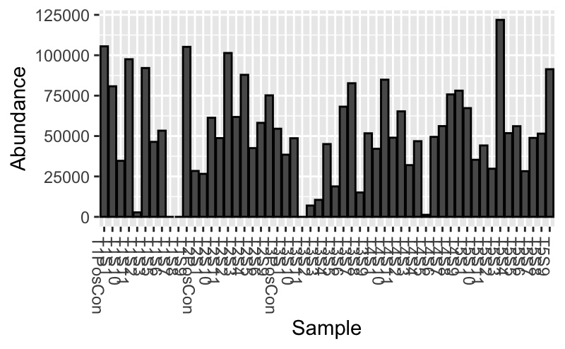

```r
# First aglomerate the ASVs at the phylum level using the phyloseq function, tax_glom
superkingdomGlommed = tax_glom(ps, "superkingdom")

# and plot
plot_bar(superkingdomGlommed, x = "Sample")

ggsave(filename = "Figures/seqdepth.eps", plot = plot_bar(superkingdomGlommed, x = "Sample"), units = c("in"), width = 9, height = 6, dpi = 300, )# and save
```

Total sequences reveals certain samples had very low sequencing effort: T1S7, T1S8, T3S11, and, not as bad, T1S2 and T4S5

The rarefaction analysis also showed T1S2 and T4S5 samples were likely not sequenced to completion. Therefore remove these 5 samples from analysis

```r
ps <- subset_samples(ps, !SampleID == "T1S7" & !SampleID == "T1S8" & !SampleID == "T3S11" & !SampleID == "T1S2" & !SampleID == "T4S5")

ps
```

```
phyloseq-class experiment-level object
otu_table()   OTU Table:         [ 368 taxa and 50 samples ]
sample_data() Sample Data:       [ 50 samples by 8 sample variables ]
tax_table()   Taxonomy Table:    [ 368 taxa by 8 taxonomic ranks ]
```

50 samples remaining with 368 ASVs

Remove Pos Controls (all hits in positive controls are the same family- I assume this is expected)

```r
ps <- subset_samples(ps, !SampleID == "T1PosCon" & !SampleID == "T2PosCon" & !SampleID == "T3PosCon")
ps
```

```
phyloseq-class experiment-level object
otu_table()   OTU Table:         [ 368 taxa and 47 samples ]
sample_data() Sample Data:       [ 47 samples by 8 sample variables ]
tax_table()   Taxonomy Table:    [ 368 taxa by 8 taxonomic ranks ]
```

And lastly, correct some taxonomy: According to Sara, Engraulis encrasicolus (European anchovy) should be Anchoa mitchilli (Bay anchovy):

```r
tax_table(ps) <- gsub(tax_table(ps), pattern = "Engraulis encrasicolus", replacement = "Anchoa mitchilli")
```

47 samples remainwith 368 unique ASVs

# Abundance plots eDNA

For plotting, use *relative abundances* (# of ASV sequences/sum total sequences in sample), calculated easily using microbiome::transform

```r
ps_ra <- microbiome::transform(ps, transform = "compositional")
```

Export the relative abundance matrix so Sara can have it:

```r
# Extract abundance matrix from the phyloseq object
RelAbun_matrix = as(otu_table(ps_ra), "matrix")

# Coerce to data.frame
RelAbun_dataframe = as.data.frame(RelAbun_matrix)

# Export
write.csv(RelAbun_dataframe,"results/otutable_relabun.csv", row.names = TRUE)
```

## Abundance at family level

Then aglomerate the ASVs at the family level using the phyloseq function, tax_glom

[figure not shown]

```r
familyGlommed_RA = tax_glom(ps_ra, "family")
family_barplot <- plot_bar(familyGlommed_RA, x = "Sample", fill = "family")
family_barplot
```

**NOTES** for Sara

- There are some samples, (T1S3, T1S6, T2S11, T3S10, T3S4, T3S5, T3S9, T4S4, T4S7, T5S7) which are composed almost exclusively of 1 family. This might be fine, but I’m not used to seeing this with prokaroytic data. Just want to check with you

Agglomerate by species to see if I get the same 38 unique species Sara sees:

```r
speciesGlommed_RA = tax_glom(ps_ra, "CommonName")
speciesGlommed_RA
```

```
phyloseq-class experiment-level object
otu_table()   OTU Table:         [ 43 taxa and 47 samples ]
sample_data() Sample Data:       [ 47 samples by 8 sample variables ]
tax_table()   Taxonomy Table:    [ 43 taxa by 8 taxonomic ranks ]
```

```r
tax_table(speciesGlommed_RA)
```

```
Taxonomy Table:     [43 taxa by 8 taxonomic ranks]:
        superkingdom phylum     class            order                family
Seq_1   "Eukaryota"  "Chordata" "Actinopteri"    "Atheriniformes"     "Atherinopsidae"
Seq_2   "Eukaryota"  "Chordata" "Actinopteri"    "Clupeiformes"       "Clupeidae"
Seq_3   "Eukaryota"  "Chordata" "Actinopteri"    "Clupeiformes"       "Engraulidae"
Seq_4   "Eukaryota"  "Chordata" "Actinopteri"    "Scombriformes"      "Pomatomidae"
Seq_5   "Eukaryota"  "Chordata" "Actinopteri"    "Lutjaniformes"      "Lutjanidae"
Seq_6   "Eukaryota"  "Chordata" "Actinopteri"    "Pleuronectiformes"  "Paralichthyidae"
Seq_7   "Eukaryota"  "Chordata" "Actinopteri"    "Clupeiformes"       "Clupeidae"
Seq_9   "Eukaryota"  "Chordata" "Actinopteri"    "Gobiiformes"        "Gobiidae"
Seq_10  "Eukaryota"  "Chordata" "Actinopteri"    "Pleuronectiformes"  "Scophthalmidae"
Seq_11  "Eukaryota"  "Chordata" "Actinopteri"    "Perciformes"        "Serranidae"
Seq_12  "Eukaryota"  "Chordata" "Actinopteri"    "Spariformes"        "Sparidae"
Seq_15  "Eukaryota"  "Chordata" "Actinopteri"    NA                   "Sciaenidae"
Seq_16  "Eukaryota"  "Chordata" "Actinopteri"    NA                   "Sciaenidae"
Seq_17  "Eukaryota"  "Chordata" "Actinopteri"    "Labriformes"        "Labridae"
Seq_19  "Eukaryota"  "Chordata" "Actinopteri"    "Perciformes"        "Cottidae"
Seq_20  "Eukaryota"  "Chordata" "Actinopteri"    "Pleuronectiformes"  "Pleuronectidae"
Seq_21  "Eukaryota"  "Chordata" "Actinopteri"    NA                   "Moronidae"
Seq_22  "Eukaryota"  "Chordata" "Actinopteri"    "Syngnathiformes"    "Syngnathidae"
Seq_30  "Eukaryota"  "Chordata" "Actinopteri"    "Pleuronectiformes"  "Paralichthyidae"
Seq_33  "Eukaryota"  "Chordata" "Actinopteri"    NA                   "Sciaenidae"
Seq_34  "Eukaryota"  "Chordata" "Actinopteri"    "Labriformes"        "Labridae"
Seq_36  "Eukaryota"  "Chordata" "Actinopteri"    "Anguilliformes"     "Anguillidae"
Seq_38  "Eukaryota"  "Chordata" "Actinopteri"    "Scombriformes"      "Scombridae"
Seq_40  "Eukaryota"  "Chordata" "Actinopteri"    "Perciformes"        "Gasterosteidae"
Seq_44  "Eukaryota"  "Chordata" "Actinopteri"    "Cyprinodontiformes" "Fundulidae"
Seq_50  "Eukaryota"  "Chordata" "Actinopteri"    "Atheriniformes"     "Atherinopsidae"
Seq_52  "Eukaryota"  "Chordata" "Actinopteri"    "Gadiformes"         "Phycidae"
Seq_54  "Eukaryota"  "Chordata" "Actinopteri"    "Scombriformes"      "Scombridae"
Seq_57  "Eukaryota"  "Chordata" "Actinopteri"    "Perciformes"        "Triglidae"
Seq_67  "Eukaryota"  "Chordata" "Actinopteri"    "Scombriformes"      "Scombridae"
Seq_82  "Eukaryota"  "Chordata" "Actinopteri"    NA                   "Sciaenidae"
Seq_84  "Eukaryota"  "Chordata" "Actinopteri"    "Gadiformes"         "Gadidae"
Seq_102 "Eukaryota"  "Chordata" "Actinopteri"    "Clupeiformes"       "Engraulidae"
Seq_103 "Eukaryota"  "Chordata" "Actinopteri"    "Perciformes"        "Cottidae"
Seq_115 "Eukaryota"  "Chordata" "Actinopteri"    "Cyprinodontiformes" "Fundulidae"
Seq_119 "Eukaryota"  "Chordata" "Actinopteri"    "Gadiformes"         "Phycidae"
Seq_139 "Eukaryota"  "Chordata" "Actinopteri"    "Batrachoidiformes"  "Batrachoididae"
Seq_141 "Eukaryota"  "Chordata" "Actinopteri"    "Scombriformes"      "Scombridae"
```

[output cut: 34 more lines]

```
Seq_57  "Prionotus"          "Prionotus carolinus"           "Northern searobin"
Seq_67  "Thunnus"            "Thunnus thynnus"               "Atlantic bluefin tuna"
Seq_82  "Bairdiella"         "Bairdiella chrysoura"          "American silver perch"
Seq_84  "Microgadus"         "Microgadus tomcod"             "Atlantic tomcod"
Seq_102 "Engraulis"          "Engraulis mordax"              "Bay anchovy"
Seq_103 "Myoxocephalus"      "Myoxocephalus quadricornis"    "Fourhorn sculpin"
Seq_115 "Fundulus"           "Fundulus heteroclitus"         "Mummichog"
Seq_119 "Urophycis"          "Urophycis floridana"           "Red hake"
Seq_139 "Opsanus"            "Opsanus tau"                   "Oyster toadfish"
Seq_141 "Katsuwonus"         "Katsuwonus pelamis"            "Skipjack tuna"
Seq_181 "Sphoeroides"        "Sphoeroides maculatus"         "Northern puffer"
Seq_231 "Merluccius"         "Merluccius bilinearis"         "Silver hake"
Seq_359 "Prionotus"          "Prionotus evolans"             "Striped searobin"
Seq_362 "Rhinoptera"         "Rhinoptera bonasus"            "Cownose ray"
Seq_372 "Mustelus"           "Mustelus canis"                "Dusky smooth-hound shark"
```

**NOTES** for Sara

- I am getting 43 unique species- which ones am I missing that should be removed?
- Also there are two species you are calling Bay anchovy- Engraulis mordax and Anchoa mitchilli. Should the Engraulis mordax be changed to Anchoa mitchilli, similar to Engraulis encrasicolus ?

## Bubble plots

Based on my previous [scripts](https://github.com/lizsuter/Cariaco_Euk) with Cariaco Eukaryotic data

```r
# convert ps object to dataframe using phyloseq's psmelt
species_df <- psmelt(speciesGlommed_RA)

# replace zeroes in the table with NA
species_df[species_df == 0] <- NA

# and remove rows with NAs in abundance  (this is so they don't appear as small dots in plot)
species_df <-  filter(species_df, !is.na(Abundance))
```

Plot by species, scientific name

[figure not shown]

```r
speciesbubbleplot_eDNA_sciname <- ggplot(species_df, aes(x = Station, y = fct_rev(species), color = Station)) + # the fancy stuff around y (species) helps to present it in reverse order in the plot (from top to btm alphabetically)
  geom_point(aes(size = Abundance, fill = Station), color = "black", pch = 21)+
  scale_size(range = c(1,15)) +
  scale_size_area(breaks = c(0,.25,.5,.75,1), max_size = 6)+
  xlab("")+
  ylab("")+
  labs(size="Relative Abundance")+
  theme_bw() +
  scale_fill_brewer(palette="Paired") +
  theme(axis.title.x=element_blank(),
        axis.text.x=element_blank(),
        axis.ticks.x=element_blank()) +
  facet_grid(Datecode~Bayside, scales = "free", space = "free", drop= TRUE)
speciesbubbleplot_eDNA_sciname
```

Plot by species common name

[figure not shown]

```r
speciesbubbleplot_eDNA_comname <- ggplot(species_df, aes(x = Station, y = fct_rev(CommonName), color = Station)) + # the fancy stuff around y (CommonName) helps to present it in reverse order in the plot (from top to btm alphabetically)
  geom_point(aes(size = Abundance, fill = Station), color = "black", pch = 21)+
  scale_size(range = c(1,15)) +
  scale_size_area(breaks = c(0,.25,.5,.75,1), max_size = 6)+
  xlab("")+
  ylab("")+
  labs(size="Relative Abundance")+
  theme_bw() +
  scale_fill_brewer(palette="Paired") +
  theme(axis.title.x=element_blank(),
        axis.text.x=element_blank(),
        axis.ticks.x=element_blank()) +
  facet_grid(Datecode~Bayside, scales = "free", space = "free", drop= TRUE)
speciesbubbleplot_eDNA_comname
```

Exportfigures

```r
ggsave(filename = "Figures/speciesbubbleplot_eDNA_sciname.eps", plot = speciesbubbleplot_eDNA_sciname, units = c("in"), width = 7, height = 12, dpi = 300)

ggsave(filename = "Figures/speciesbubbleplot_eDNA_comname.eps", plot = speciesbubbleplot_eDNA_comname, units = c("in"), width = 7, height = 12, dpi = 300)
```

**NOTE** on above. The common name plot has two entries in the Bay anchovy row because, as mentioned above, there are two different species name that are labelled as Bay Anchovy. Is it OK to group these as same species (Anchoa mitchilli)

# Import and prepare the data from trawls

## Import Trawl Master sheet

```r
# import 4th sheet from  Excel file which contains morphometric data for each individual collected for every date
trawl_master <- read_excel("Trawls MASTER 2020 _mod_ES.xlsx",4)
trawl_master
```

| DATECODE | YEAR | STATION_NO | TRAWL | DATECODE.STATION_NO | COMMONNAME | CommonName | GROUP | TL_CM | FL_CM | WIDTH_CM | SEX | REPRODUCTIVE STATUS | DATANOTES | TRAWL_TIME | BAYSIDE | BAYSIDEYEAR | HABITAT | STATION_NAME |
| --- | --- | --- | --- | --- | --- | --- | --- | --- | --- | --- | --- | --- | --- | --- | --- | --- | --- | --- |
| 20200707 | 2020 | 12 | 1 | 20200707.12 | ATLANTIC SILVERSIDE | Atlantic silverside | FISH | 5.800 | 5.500 | NA | NA | NA | NA | NA | NA | NA | NA | NA |
| 20200707 | 2020 | 12 | 1 | 20200707.12 | ATLANTIC SILVERSIDE | Atlantic silverside | FISH | 5.000 | 4.700 | NA | NA | NA | NA | NA | NA | NA | NA | NA |
| 20200707 | 2020 | 12 | 1 | 20200707.12 | ATLANTIC SILVERSIDE | Atlantic silverside | FISH | 5.100 | 4.900 | NA | NA | NA | NA | NA | NA | NA | NA | NA |
| 20200707 | 2020 | 12 | 1 | 20200707.12 | ATLANTIC SILVERSIDE | Atlantic silverside | FISH | 5.400 | 5.100 | NA | NA | NA | NA | NA | NA | NA | NA | NA |
| 20200707 | 2020 | 12 | 1 | 20200707.12 | ATLANTIC SILVERSIDE | Atlantic silverside | FISH | 4.600 | 4.400 | NA | NA | NA | NA | NA | NA | NA | NA | NA |
| 20200707 | 2020 | 12 | 1 | 20200707.12 | ATLANTIC SILVERSIDE | Atlantic silverside | FISH | 3.700 | 3.400 | NA | NA | NA | NA | NA | NA | NA | NA | NA |
| 20200707 | 2020 | 12 | 1 | 20200707.12 | ATLANTIC SILVERSIDE | Atlantic silverside | FISH | 4.700 | 4.500 | NA | NA | NA | NA | NA | NA | NA | NA | NA |
| 20200707 | 2020 | 12 | 1 | 20200707.12 | ATLANTIC SILVERSIDE | Atlantic silverside | FISH | 4.500 | 4.300 | NA | NA | NA | NA | NA | NA | NA | NA | NA |
| 20200707 | 2020 | 12 | 1 | 20200707.12 | ATLANTIC SILVERSIDE | Atlantic silverside | FISH | 4.700 | 4.500 | NA | NA | NA | NA | NA | NA | NA | NA | NA |
| 20200707 | 2020 | 12 | 1 | 20200707.12 | ATLANTIC SILVERSIDE | Atlantic silverside | FISH | 5.100 | 4.800 | NA | NA | NA | NA | NA | NA | NA | NA | NA |

[output cut: 990 more lines]

```r
# and import 6th sheet which is station info
stations <- read_excel("Trawls MASTER 2020 _mod_ES.xlsx",6)
stations
```

| STATION_NO | STATION_NA | BAYSIDE |
| --- | --- | --- |
| 1 | SHINNECOCK HILLS | EAST |
| 2 | CORMORANT POINT | EAST |
| 3 | INLET | EAST |
| 4 | PONQUOGUE BRIDGE | EAST |
| 7 | LITTLE POND | EAST |
| 8 | WEST TIANA | WEST |
| 9 | DUNE ROAD | WEST |
| 10 | WEST MID BAY | WEST |
| 11 | SOUTH GRASS | EAST |
| 12 | PINE NECK | WEST |

[output cut: 1 more lines]

```r
NA
```

## Convert to count table

Make an equivalent to an OTU table, grouping by date and location and representing counts for every unique species

```r
trawl_counts <- trawl_master %>%
  group_by(DATECODE, STATION_NO, CommonName) %>%
  tally(name = "count")

trawl_counts
```

| DATECODE | STATION_NO | CommonName | count |
| --- | --- | --- | --- |
| 20200707 | 1 | Atlantic silverside | 1 |
| 20200707 | 1 | Blue crab | 10 |
| 20200707 | 1 | Cunner | 5 |
| 20200707 | 1 | Grass shrimp | 1 |
| 20200707 | 1 | Northern pipefish | 2 |
| 20200707 | 1 | Sand shrimp | 1 |
| 20200707 | 1 | Summer flounder | 1 |
| 20200707 | 1 | Tautog | 1 |
| 20200707 | 1 | Winter flounder | 5 |
| 20200707 | 2 | Atlantic silverside | 1 |

[output cut: 421 more lines]

and link station names instead of numbers to count table

```r
trawl_counts <- left_join(trawl_counts, stations, by = "STATION_NO")
trawl_counts
```

| DATECODE | STATION_NO | CommonName | count | STATION_NA | BAYSIDE |
| --- | --- | --- | --- | --- | --- |
| 20200707 | 1 | Atlantic silverside | 1 | SHINNECOCK HILLS | EAST |
| 20200707 | 1 | Blue crab | 10 | SHINNECOCK HILLS | EAST |
| 20200707 | 1 | Cunner | 5 | SHINNECOCK HILLS | EAST |
| 20200707 | 1 | Grass shrimp | 1 | SHINNECOCK HILLS | EAST |
| 20200707 | 1 | Northern pipefish | 2 | SHINNECOCK HILLS | EAST |
| 20200707 | 1 | Sand shrimp | 1 | SHINNECOCK HILLS | EAST |
| 20200707 | 1 | Summer flounder | 1 | SHINNECOCK HILLS | EAST |
| 20200707 | 1 | Tautog | 1 | SHINNECOCK HILLS | EAST |
| 20200707 | 1 | Winter flounder | 5 | SHINNECOCK HILLS | EAST |
| 20200707 | 2 | Atlantic silverside | 1 | CORMORANT POINT | EAST |

[output cut: 421 more lines]

Remove 09/16/20 since there is no equivalent eDNA from that date

```r
trawl_counts <- trawl_counts %>%
  filter(DATECODE != "20200916")

trawl_counts
```

| DATECODE | STATION_NO | CommonName | count | STATION_NA | BAYSIDE |
| --- | --- | --- | --- | --- | --- |
| 20200707 | 1 | Atlantic silverside | 1 | SHINNECOCK HILLS | EAST |
| 20200707 | 1 | Blue crab | 10 | SHINNECOCK HILLS | EAST |
| 20200707 | 1 | Cunner | 5 | SHINNECOCK HILLS | EAST |
| 20200707 | 1 | Grass shrimp | 1 | SHINNECOCK HILLS | EAST |
| 20200707 | 1 | Northern pipefish | 2 | SHINNECOCK HILLS | EAST |
| 20200707 | 1 | Sand shrimp | 1 | SHINNECOCK HILLS | EAST |
| 20200707 | 1 | Summer flounder | 1 | SHINNECOCK HILLS | EAST |
| 20200707 | 1 | Tautog | 1 | SHINNECOCK HILLS | EAST |
| 20200707 | 1 | Winter flounder | 5 | SHINNECOCK HILLS | EAST |
| 20200707 | 2 | Atlantic silverside | 1 | CORMORANT POINT | EAST |

[output cut: 353 more lines]

# Abundance plots Trawls

[figure not shown]

```r
speciesbubbleplot_trawl_comname <- ggplot(trawl_counts, aes(x = STATION_NA, y = fct_rev(CommonName), color = STATION_NA)) +
  geom_point(aes(size = log10(count), fill = STATION_NA), color = "black", pch = 21)+
  scale_size(range = c(1,15)) +
  scale_size_area(breaks = c(.01,.1, .3, .5, 1, 3), max_size = 6)+
  xlab("")+
  ylab("")+
  labs(size="Log(counts)", fill = "Station")+
  theme_bw() +
  scale_fill_brewer(palette="Paired") +
  theme(axis.title.x=element_blank(),
        axis.text.x=element_blank(),
        axis.ticks.x=element_blank()) +
  facet_grid(DATECODE~BAYSIDE, scales = "free", space = "free", drop= TRUE)
speciesbubbleplot_trawl_comname
```

Export figure

```r
ggsave(filename = "Figures/speciesbubbleplot_trawl_comname.eps", plot = speciesbubbleplot_trawl_comname, units = c("in"), width = 6.75, height = 13, dpi = 300)
```

# Abundance Plots Compare Trawl and eDNA

Count unique species across all stations, grouped by date, for each method (trawl, eDNA)

```r
trawl_uniques <- trawl_counts %>%
  group_by(DATECODE, CommonName) %>%
  summarise(Trawl_Count = sum(count, na.rm=TRUE))
trawl_uniques
```

| DATECODE | CommonName | Trawl_Count |
| --- | --- | --- |
| 20200707 | Atlantic silverside | 186 |
| 20200707 | Atlantic tomcod | 2 |
| 20200707 | Bay anchovy | 1 |
| 20200707 | Black sea bass | 2 |
| 20200707 | Blue crab | 36 |
| 20200707 | Butterfish | 1 |
| 20200707 | Clearnose skate | 1 |
| 20200707 | Cunner | 9 |
| 20200707 | Grass shrimp | 7 |
| 20200707 | Green crab | 1 |

[output cut: 108 more lines]

```r
eDNA_uniques <- species_df%>%
  group_by(Datecode, CommonName) %>%
  summarise(eDNA_RelAbun = sum(Abundance, na.rm=TRUE))
eDNA_uniques
```

| Datecode | CommonName | eDNA_RelAbun |
| --- | --- | --- |
| 20200707 | American eel | 1.292936e-04 |
| 20200707 | Atlantic menhaden | 3.440720e-01 |
| 20200707 | Atlantic silverside | 2.611869e+00 |
| 20200707 | Bay anchovy | 1.070033e+00 |
| 20200707 | Bluefish | 4.559755e-02 |
| 20200707 | Grubby sculpin | 2.639098e-01 |
| 20200707 | Hickory shad | 7.109103e-01 |
| 20200707 | Mummichog | 3.711717e-03 |
| 20200707 | Northern kingfish | 2.255102e-01 |
| 20200707 | Northern pipefish | 2.794035e-01 |

[output cut: 76 more lines]

```r
# Combine into one dataframe
trawl_eDNA_abun_table <- full_join(trawl_uniques, eDNA_uniques, by=c("CommonName" = "CommonName", "DATECODE" = "Datecode"))

trawl_eDNA_abun_table
```

| DATECODE | CommonName | Trawl_Count | eDNA_RelAbun |
| --- | --- | --- | --- |
| 20200707 | Atlantic silverside | 186 | 2.611869e+00 |
| 20200707 | Atlantic tomcod | 2 | NA |
| 20200707 | Bay anchovy | 1 | 1.070033e+00 |
| 20200707 | Black sea bass | 2 | NA |
| 20200707 | Blue crab | 36 | NA |
| 20200707 | Butterfish | 1 | NA |
| 20200707 | Clearnose skate | 1 | NA |
| 20200707 | Cunner | 9 | NA |
| 20200707 | Grass shrimp | 7 | NA |
| 20200707 | Green crab | 1 | NA |

[output cut: 155 more lines]

Count total number of species from each method for each date

```r
eDNA_richness <- tally(eDNA_uniques, name = "eDNA")
trawl_richness <- tally(trawl_uniques, name = "trawl")

speciesrichness <- full_join(eDNA_richness, trawl_richness, c("Datecode" = "DATECODE"))
speciesrichness <- pivot_longer(speciesrichness, !Datecode, names_to = "Method", values_to = "Richness")

speciesrichness$Datecode <- ymd(speciesrichness$Datecode) # convert to date format (better for plotting)

speciesrichness
```

| Datecode | Method | Richness |
| --- | --- | --- |
| 2020-07-07 | eDNA | 16 |
| 2020-07-07 | trawl | 20 |
| 2020-07-22 | eDNA | 26 |
| 2020-07-22 | trawl | 25 |
| 2020-08-05 | eDNA | 15 |
| 2020-08-05 | trawl | 29 |
| 2020-08-19 | eDNA | 11 |
| 2020-08-19 | trawl | 21 |
| 2020-09-02 | eDNA | 18 |
| 2020-09-02 | trawl | 23 |

Plot side-by-side

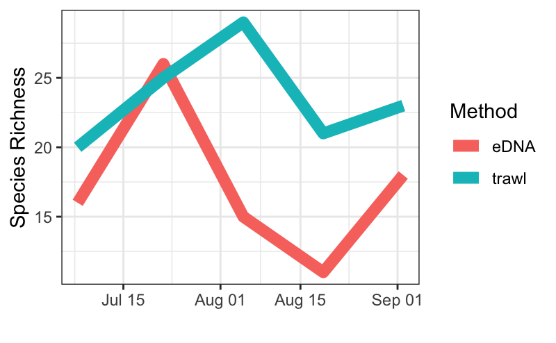

```r
species_richness_plot <- ggplot(speciesrichness, aes(x =Datecode, y = Richness)) +
  geom_line(aes(color = Method), size = 3) +
  theme_bw() +
  xlab("") +
  ylab("Species Richness")

species_richness_plot

# export plot
ggsave(filename = "Figures/species_richness_plot.eps", plot = species_richness_plot, units = c("in"), width = 4, height = 3, dpi = 300)
```

Sum total number of species across all dates/ stations for entire study

```r
species_sums_abun_table <- trawl_eDNA_abun_table %>%
  group_by(CommonName) %>%
  summarise(Trawl = sum(Trawl_Count, na.rm=TRUE), eDNA = (sum(eDNA_RelAbun, na.rm=TRUE))) %>%
  pivot_longer(!CommonName, names_to = "Method", values_to = "Abundance")
# turn zeroes to NA so they don't plot
species_sums_abun_table <- na_if(species_sums_abun_table,0)

species_sums_abun_table
```

| CommonName | Method | Abundance |
| --- | --- | --- |
| American eel | Trawl | 1.000000e+00 |
| American eel | eDNA | 7.918773e-02 |
| American silver perch | Trawl | NA |
| American silver perch | eDNA | 8.526155e-02 |
| Atlantic bluefin tuna | Trawl | NA |
| Atlantic bluefin tuna | eDNA | 4.117434e-02 |
| Atlantic menhaden | Trawl | 1.000000e+02 |
| Atlantic menhaden | eDNA | 1.303442e+01 |
| Atlantic silverside | Trawl | 3.000000e+02 |
| Atlantic silverside | eDNA | 1.382721e+01 |

[output cut: 96 more lines]

For each species, plot side-by-side comparison of abundance (summed over whole study) using each method

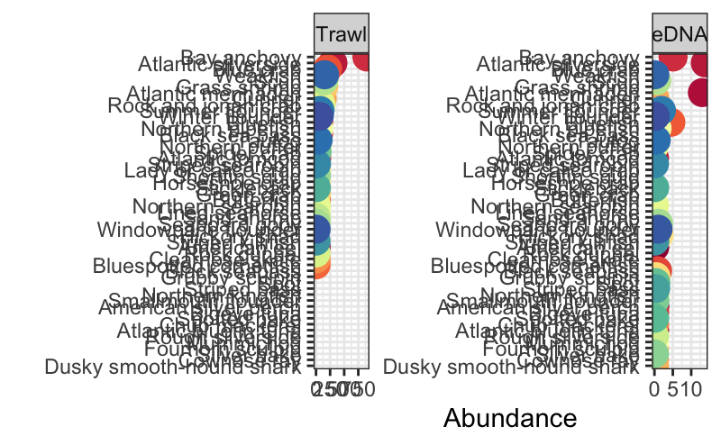

```r
# First create a custom color scale to make this pretty
myColors <- colorRampPalette(brewer.pal(11,"Spectral"))(55)
names(myColors) <- levels(unique(species_sums_abun_table$CommonName))
colScale <- scale_colour_manual(name = "CommonName",values = myColors)

species_abun_sum_plot <- ggplot(species_sums_abun_table, aes(x = Abundance, y = reorder(CommonName, Abundance, function(x){sum(x,na.rm = TRUE)}), color = CommonName)) +
  geom_point(size = 5) +
  facet_wrap(~fct_rev(Method), scales = "free") +
  theme_bw() +
  xlab("Abundance") +
  ylab("") +
  colScale +
  theme(legend.position = "none")

species_abun_sum_plot
```

Export plot

```r
ggsave(filename = "Figures/species_abun_sum_plot.eps", plot = species_abun_sum_plot, units = c("in"), width = 7, height = 8, dpi = 300)
```

# Exploratory Analyses

## Ordinations on eDNA

### PCA

PCA is essentially a type of PCoA using the Euclidean distance matrix as input. When combined with a log-ratio transformation of the count table, this is deemed appropriate for *compositional* datasets. It is also [recommended](https://sites.google.com/site/mb3gustame/indirect-gradient-analysis/pca) as a first step in exploratory analyses of sequencinging datasets.

First do a **CLR, centered log ratio** transformation of the absolute abundance data (after filtering), as suggested by [Gloor et al. 2017](https://www.frontiersin.org/articles/10.3389/fmicb.2017.02224/full)

```r
# Estimate covariance matrix for CLR-transformed ASV table
clr_asv_table_ps <- data.frame(compositions::clr(otu_table(ps)))
```

Generate the PCA and visualize axes

```r
# Generate a Principle Component Analysis (PCA) and evaluated based on the eigen decomposition from sample covariance matrix.
lograt_pca <- prcomp(clr_asv_table_ps)
# NOTE- this is equivalent to first making a Euclidean distance matrix using the CLR data table and then running a PCoA. A Euclidean distance matrix of a log-transformed data table = an Aitchison distance matrix. So this is equivalent to the compositional methods listed in Gloor et al.

# Visual representation with a screeplot
lograt_variances <- as.data.frame(lograt_pca$sdev^2/sum(lograt_pca$sdev^2)) %>% #Extract axes
  # Format to plot
  select(PercVar = 'lograt_pca$sdev^2/sum(lograt_pca$sdev^2)') %>%
  rownames_to_column(var = "PCaxis") %>%
  data.frame
head(lograt_variances)
```

|  | PCaxis | PercVar |
| --- | --- | --- |
| 1 | 1 | 0.15679370 |
| 2 | 2 | 0.10545429 |
| 3 | 3 | 0.09950603 |
| 4 | 4 | 0.06977647 |
| 5 | 5 | 0.04623742 |
| 6 | 6 | 0.04414957 |

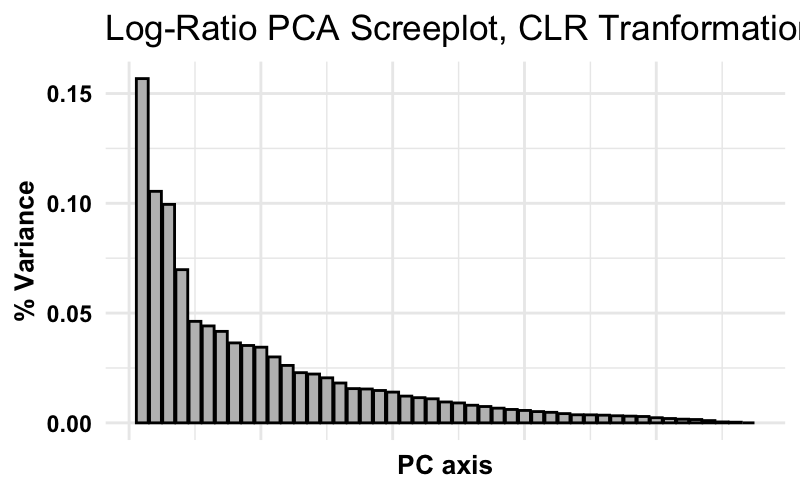

```r
# Plot screeplot
ggplot(lograt_variances, aes(x = as.numeric(PCaxis), y = PercVar)) +
  geom_bar(stat = "identity", fill = "grey", color = "black") +
  theme_minimal() +
  theme(axis.title = element_text(color = "black", face = "bold", size = 10),
        axis.text.y = element_text(color = "black", face = "bold"),
        axis.text.x = element_blank()) +
  labs(x = "PC axis", y = "% Variance", title = "Log-Ratio PCA Screeplot, CLR Tranformation")
```

Plot in 3D using first 3 axes since the 2nd and 3rd are similar proportions of variance. Total variance explained by first three: 15.7 + 10.5 + 10.0 = 36.2%)

Visualize the PCA-

```
There were 14 warnings (use warnings() to see them)
```

```r
# Extract variances from the clr pca
pca_lograt_frame <- data.frame(lograt_pca$x) %>%
  rownames_to_column(var = "SampleID")

# Merge metadata into the pcoa data table
pca_lograt_frame <- left_join(pca_lograt_frame, metadata, by = "SampleID")
head(pca_lograt_frame)
```

|  | SampleID | PC1 | PC2 | PC3 | PC4 | PC5 | PC6 | PC7 | PC8 | PC9 | PC10 | PC11 | PC12 | PC13 | PC14 | PC15 | PC16 | PC17 | PC18 | PC19 | PC20 | PC21 | PC22 | PC23 | PC24 | PC25 | PC26 | PC27 | PC28 | … |
| --- | --- | --- | --- | --- | --- | --- | --- | --- | --- | --- | --- | --- | --- | --- | --- | --- | --- | --- | --- | --- | --- | --- | --- | --- | --- | --- | --- | --- | --- | --- |
| 1 | T1S10 | -2.6238954 | -0.3252536 | 1.2700571 | -1.666211 | 0.79864997 | -0.5784819 | 0.247580998 | -0.5587116 | 1.5405134 | -1.0025776 | 0.2259772 | -0.4959160 | 0.62088813 | -0.1113515 | -0.9031760 | 0.0521750 | 0.5163660 | 0.1164691 | -1.1361756 | -0.9397402 | 0.1455318 | 0.4448877 | 0.03055507 | -0.1042593 | -0.4649432055 | 0.35588181 | 0.17992733 | 0.7760907427 | … |
| 2 | T1S11 | 0.2705609 | -4.0749320 | -6.6693172 | 2.284305 | 2.67232691 | -0.4101805 | -0.526654868 | -0.4623241 | -0.4162992 | -1.2299269 | -0.3387591 | -2.4793779 | -1.92292360 | -1.6172767 | 1.4262978 | 2.6333997 | -1.7751184 | -0.6439386 | -0.1637926 | -1.1708437 | 1.3830018 | 0.9790991 | 0.21170322 | 0.1511695 | -0.8685434581 | 1.04940523 | -1.10236127 | 0.0002552213 | … |
| 3 | T1S1 | -2.7027302 | 2.5315244 | 0.4277067 | -2.891886 | -0.08919948 | -2.0274127 | -1.526307265 | 4.5079185 | -2.8016160 | 0.9928165 | 0.4210186 | 0.6544221 | 0.05542544 | 1.0570612 | 1.0137754 | 1.7488098 | 0.6033360 | -2.1118611 | -3.0962656 | 1.7816513 | 0.3400991 | -0.2716390 | -0.90334541 | 1.3006938 | -0.5473422995 | -0.04802231 | -0.10948686 | -0.9587529174 | … |
| 4 | T1S3 | -2.1044928 | 1.0756380 | 1.4904589 | -2.219958 | -0.06137715 | -0.3849491 | 0.320469272 | -1.0122575 | 1.4274917 | -0.6529554 | 0.2193231 | -0.6500125 | 0.19899498 | -0.4299291 | -0.1718749 | -0.3211078 | -0.2955996 | -0.6290764 | -0.9816539 | -0.4209648 | 0.8699468 | 0.2469139 | -0.15851951 | 0.1250575 | -1.1016182738 | 0.05939611 | 0.01323105 | 1.2624136272 | … |
| 5 | T1S5 | -1.7135917 | 1.1790076 | 2.7747405 | -1.340063 | -1.36423205 | 0.2410250 | -0.009868407 | -0.9586005 | 1.6624010 | 1.9024914 | 0.9023628 | 2.3704172 | -0.90409728 | -5.9584689 | -0.9903991 | 2.3237480 | 1.8740664 | -0.5223559 | 0.4761580 | -0.5389552 | -0.2800462 | -0.6001360 | -0.22563816 | -0.2240815 | -0.0009001045 | -0.79442974 | -0.71040916 | -0.7007108564 | … |
| 6 | T1S6 | -1.6263823 | -0.7382611 | 4.9253340 | -2.100496 | -0.99285548 | 1.3100566 | 2.080679436 | -0.2911133 | -0.5302369 | -0.4818129 | 0.3249269 | -0.5825091 | -3.36962676 | 1.0385081 | 2.9251040 | 0.5273225 | 0.7428352 | 1.9827115 | -0.9076978 | 0.2082579 | 0.3025107 | 1.8929888 | 1.47924904 | -2.0566843 | 0.6892908892 | -0.36424583 | -0.08183022 | -0.8163892316 | … |

```r
# Select eigenvalues from dataframe, round to 4 places and multiply by 100 for plotting. These will be the axes for the 3-D plot
eigenvalues<-round(lograt_variances[,2], digits = 4)*100

# Plotly - 3-D
pca_lograt <- plot_ly(pca_lograt_frame, type='scatter3d', mode='markers',
        x=~PC1,y=~PC2,z=~PC3,colors=~brewer.pal(11,'Paired'),
        color=~Station, symbols = c('circle','diamond'), symbol=~Bayside)%>%
  layout(font=list(size=12),
         title='CLR-Euclidean PCA',
         scene=list(xaxis=list(title=paste0('Co 2 ',eigenvalues[2],'%'),
                               showticklabels=FALSE,zerolinecolor='black'),
                    yaxis=list(title=paste0('Co 3 ',eigenvalues[3],'%'),
                               showticklabels=FALSE,zerolinecolor='black'),
                    zaxis=list(title=paste0('Co 1 ',eigenvalues[1],'%'),
                               showticklabels=FALSE,zerolinecolor='black')))
# pca_lograt

# save in "Embedded_figures" directory so that it can be hosted at Github and embedded in this notebook
withr::with_dir('Embedded_figures', htmlwidgets::saveWidget(as_widget(pca_lograt), file="pca_lograt.html", selfcontained = F))
```

The CLR-Euclidean PCA reveals there is some separation according to East vs West. The PCA only explains ~36% of the variance so keep going with different ordinations to see if we can get a better representation

Test embedding image in-line instead of as code chunk:

[interactive chart not shown]

*This is working locally but not on github. Come back and check later to see if it’s just a temp problem*

### PCoA Jaccard

The more traditional approach to ordinations is to do a PCoA on a distance matrix such as Bray-Curtis, Jaccard, or Unifrac. While these are not considered compositional approaches, when combined with pre-treatment (transformations) they become more appropriate. One such transformation that I will use here is the Hellinger transformation.

The different distance matrices also tell you a few different things about the dataset so I will run through this to try to see if I can tease those out.

Before calculating any distance matrix, do a transformation of the filtered count table. Hellinger transformation is the square root of the relative abundance, so calculate it based on the ps_ra object:

```r
ps_hellinger <- transform_sample_counts(ps_ra, function(x){sqrt(x)})
```

First, **Jaccard**, which builds the distance matrix based on presence/absence between samples. It does not take into account relative abundance of the taxa. Therefore this functions well for determining differences driven by rare taxa, which are weighed the same as abundant taxa.

```r
jac_dmat<-vegdist(otu_table(ps_hellinger),method="jaccard") # Jaccard dist metric
pcoa_jac<-ape::pcoa(jac_dmat) # perform PCoA

# Extract variances from pcoa, from jaccard calculated dist. metric
jac_variances <- data.frame(pcoa_jac$values$Relative_eig) %>%
  select(PercVar = 'pcoa_jac.values.Relative_eig') %>%
  rownames_to_column(var = "PCaxis") %>%
  data.frame
head(jac_variances)
```

|  | PCaxis | PercVar |
| --- | --- | --- |
| 1 | 1 | 0.18976509 |
| 2 | 2 | 0.09641669 |
| 3 | 3 | 0.08391737 |
| 4 | 4 | 0.04955417 |
| 5 | 5 | 0.04361026 |
| 6 | 6 | 0.03827229 |

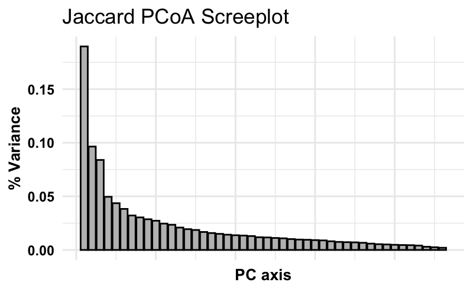

```r
# Make a screeplot
ggplot(jac_variances, aes(x = as.numeric(PCaxis), y = PercVar)) +
  geom_bar(stat = "identity", fill = "grey", color = "black") +
  theme_minimal() +
  theme(axis.title = element_text(color = "black", face = "bold", size = 10),
        axis.text.y = element_text(color = "black", face = "bold"),
        axis.text.x = element_blank()) +
  labs(x = "PC axis", y = "% Variance", title = "Jaccard PCoA Screeplot")
```

Plot in 3D with Plotly

```r
# Extract variances from the jaccard pcoa
```

```
There were 28 warnings (use warnings() to see them)
```

```r
pcoa_jac_df <- data.frame(pcoa_jac$vectors) %>%
  rownames_to_column(var = "SampleID")

# Merge metadata into the pcoa data table
pcoa_jac_df <- left_join(pcoa_jac_df, metadata, by = "SampleID")
head(pcoa_jac_df)
```

|  | SampleID | Axis.1 | Axis.2 | Axis.3 | Axis.4 | Axis.5 | Axis.6 | Axis.7 | Axis.8 | Axis.9 | Axis.10 | Axis.11 | Axis.12 | Axis.13 | Axis.14 | Axis.15 | Axis.16 | Axis.17 | Axis.18 | Axis.19 | Axis.20 | Axis.21 | Axis.22 | Axis.23 | Axis.24 | Axis.25 | Axis.26 | Axis.27 | Axis.28 | … |
| --- | --- | --- | --- | --- | --- | --- | --- | --- | --- | --- | --- | --- | --- | --- | --- | --- | --- | --- | --- | --- | --- | --- | --- | --- | --- | --- | --- | --- | --- | --- |
| 1 | T1S10 | -0.3634369 | 0.08995264 | 0.20013586 | 0.09220030 | 0.1780300 | -0.024416226 | -0.02085562 | -0.01364698 | 0.04385226 | -0.02948679 | 0.05128132 | 0.0833792504 | -0.02338622 | 0.05965336 | 0.0002478035 | 0.041358497 | -0.01368924 | 0.02803091 | -0.009899074 | -0.02457826 | 0.03553441 | -0.08427273 | 0.05451611 | 0.087328036 | -0.0006116784 | 0.047486320 | -0.0160365069 | 0.005323800 | … |
| 2 | T1S11 | -0.1017076 | -0.12950636 | 0.19545719 | 0.18226698 | 0.1256733 | 0.060979062 | 0.11210043 | 0.09745761 | -0.12733905 | 0.08795129 | -0.07654690 | -0.0475837917 | 0.07017874 | 0.06226398 | 0.0915436897 | -0.072636957 | -0.10025909 | -0.10647849 | 0.062640328 | 0.19628433 | 0.05189490 | 0.01594883 | -0.12076790 | -0.036361211 | -0.1403112693 | -0.060940268 | 0.0486003675 | 0.048126147 | … |
| 3 | T1S1 | -0.1703683 | 0.02432217 | 0.02882685 | -0.04732940 | -0.4019793 | 0.009605392 | -0.09987656 | 0.24293008 | 0.05671939 | -0.01685425 | 0.28368193 | -0.0855244824 | 0.15007908 | 0.09658706 | 0.0507330032 | 0.037447008 | -0.06911175 | -0.05083139 | 0.113997815 | 0.04730970 | -0.06901806 | 0.07275799 | 0.01591242 | 0.087949050 | 0.1027603478 | -0.002479153 | -0.0043342394 | 0.049056147 | … |
| 4 | T1S3 | -0.3306438 | 0.27772328 | 0.04789384 | -0.11333053 | 0.1646514 | 0.007798378 | -0.11757004 | 0.01751635 | 0.06307132 | -0.08798360 | 0.04418288 | 0.0001248719 | 0.01783600 | 0.00632056 | 0.0922406695 | 0.003585723 | 0.08989253 | 0.10878281 | 0.021393694 | 0.01868438 | 0.04619064 | 0.00190552 | -0.06387324 | -0.028473875 | -0.0301864425 | 0.080223036 | -0.0854356724 | 0.090879202 | … |
| 5 | T1S5 | -0.2116120 | 0.04324240 | -0.13110737 | -0.05253644 | -0.1231027 | 0.053743940 | 0.05901206 | -0.33514619 | 0.01982231 | 0.19027302 | -0.01750028 | -0.1198533871 | 0.28040948 | 0.07537405 | -0.0598105051 | -0.055437580 | 0.15826531 | 0.00160231 | 0.105175717 | -0.08315495 | 0.05492180 | 0.01483875 | -0.06624401 | -0.039965618 | -0.0238169987 | 0.025384182 | -0.0337613290 | -0.001342853 | … |
| 6 | T1S6 | 0.0144016 | -0.17758560 | 0.02345258 | -0.34025584 | -0.0416029 | 0.014571456 | -0.41202643 | 0.01436117 | -0.31865035 | 0.30486139 | -0.01485727 | 0.1966916718 | -0.08752990 | 0.02252392 | -0.0334027144 | -0.031752783 | 0.02073684 | -0.04398718 | -0.002334332 | 0.01397772 | 0.01408726 | -0.03113031 | 0.02173996 | -0.003357848 | 0.0023411670 | 0.015509510 | 0.0007398624 | 0.010396037 | … |

```r
# Select eigenvalues from dataframe, round to 4 places and multiply by 100 for plotting. These will be the axes for the 3-D plot
eigenvalues<-round(jac_variances[,2], digits = 4)*100

# Plotly - 3-D
pcoa_jaccard <- plot_ly(pcoa_jac_df, type='scatter3d', mode='markers',
        x=~Axis.2,y=~Axis.3,z=~Axis.1,colors=~brewer.pal(11,'Paired'),
        color=~Station, symbols = c('circle','diamond'), symbol=~Bayside)%>%
  layout(font=list(size=12),
         title='PCoA Jaccard Distance',
         scene=list(xaxis=list(title=paste0('Co 2 ',eigenvalues[2],'%'),
                               showticklabels=FALSE,zerolinecolor='black'),
                    yaxis=list(title=paste0('Co 3 ',eigenvalues[3],'%'),
                               showticklabels=FALSE,zerolinecolor='black'),
                    zaxis=list(title=paste0('Co 1 ',eigenvalues[1],'%'),
                               showticklabels=FALSE,zerolinecolor='black')))
# pcoa_jaccard

# save in "Embedded_figures" directory so that it can be hosted at Github and embedded in this notebook
withr::with_dir('Embedded_figures', htmlwidgets::saveWidget(as_widget(pcoa_jaccard), file="pcoa_jaccard.html", selfcontained = F))
```

The Jaccard-PCoA shows separation along axis 2 in East vs West differences.

Embed preview:

[interactive chart not shown]

*Fix, as above*

### PCoA Bray Curtis

Next, try a **Bray-Curtis** distance matrix with PCoA, which builds the distance matrix based on presence/absence between samples *and* relative abundance differences. This ordination will represent well the differences in samples that are driven by taxa with high relative abundances.

```r
bray_dmat<-vegdist(otu_table(ps_hellinger),method="bray") # Bray-Curtis dist metric
pcoa_bray<-ape::pcoa(bray_dmat) # perform PCoA

# Extract variances from pcoa, from jaccard calculated dist. metric
bray_variances <- data.frame(pcoa_bray$values$Relative_eig) %>%
  select(PercVar = 'pcoa_bray.values.Relative_eig') %>%
  rownames_to_column(var = "PCaxis") %>%
  data.frame
head(bray_variances)
```

|  | PCaxis | PercVar |
| --- | --- | --- |
| 1 | 1 | 0.27693144 |
| 2 | 2 | 0.14275707 |
| 3 | 3 | 0.12157154 |
| 4 | 4 | 0.06623888 |
| 5 | 5 | 0.05144847 |
| 6 | 6 | 0.04889064 |

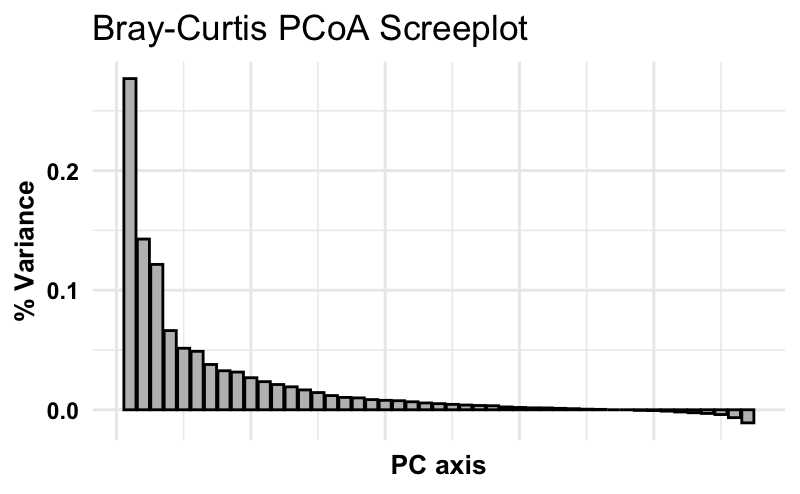

```r
# Make a screeplot
ggplot(bray_variances, aes(x = as.numeric(PCaxis), y = PercVar)) +
  geom_bar(stat = "identity", fill = "grey", color = "black") +
  theme_minimal() +
  theme(axis.title = element_text(color = "black", face = "bold", size = 10),
        axis.text.y = element_text(color = "black", face = "bold"),
        axis.text.x = element_blank()) +
  labs(x = "PC axis", y = "% Variance", title = "Bray-Curtis PCoA Screeplot")
```

The first two axes (27.7 + 14.3 = 42%) are pretty good again but I am still going to experiment in the plot with the 3rd axis since it is similar to the second (12.2% variance)

Plot in 3D with Plotly

```r
# Extract variances from the jaccard pcoa
pcoa_bray_df <- data.frame(pcoa_bray$vectors) %>%
  rownames_to_column(var = "SampleID")

# Merge metadata into the pcoa data table
pcoa_bray_df <- left_join(pcoa_bray_df, metadata, by = "SampleID")
head(pcoa_bray_df)
```

|  | SampleID | Axis.1 | Axis.2 | Axis.3 | Axis.4 | Axis.5 | Axis.6 | Axis.7 | Axis.8 | Axis.9 | Axis.10 | Axis.11 | Axis.12 | Axis.13 | Axis.14 | Axis.15 | Axis.16 | Axis.17 | Axis.18 | Axis.19 | Axis.20 | Axis.21 | Axis.22 | Axis.23 | Axis.24 | Axis.25 | Axis.26 | Axis.27 | Axis.28 | … |
| --- | --- | --- | --- | --- | --- | --- | --- | --- | --- | --- | --- | --- | --- | --- | --- | --- | --- | --- | --- | --- | --- | --- | --- | --- | --- | --- | --- | --- | --- | --- |
| 1 | T1S10 | -0.41592540 | -0.02400983 | 0.21447031 | -0.09855293 | -0.15386371 | 5.988920e-02 | -0.02105785 | -0.03940573 | 0.02748432 | 0.02651967 | -0.05167498 | -0.03041486 | 0.003431181 | 0.02170959 | -0.009286793 | 0.047050289 | -0.01555142 | 0.002011709 | 0.044704867 | 0.068041668 | -0.004151091 | -0.03585718 | 0.0307294254 | -0.054207970 | 0.036334709 | 0.020323819 | 0.060517665 | 0.005738777 | … |
| 2 | T1S11 | -0.09683179 | -0.19652997 | 0.15919782 | -0.15117891 | -0.14696547 | -2.898149e-02 | 0.04304877 | -0.00337142 | -0.10860591 | -0.06848713 | 0.16008499 | 0.06265473 | -0.016647004 | 0.03081916 | -0.180572654 | -0.081245144 | 0.11173487 | -0.033253826 | 0.074194016 | -0.092847768 | 0.011439073 | 0.02758252 | 0.0095026372 | 0.036136075 | 0.002790994 | -0.005329893 | -0.032560324 | 0.026458683 | … |
| 3 | T1S1 | -0.22379180 | 0.06412357 | 0.05535925 | 0.04724381 | 0.43448682 | -1.003965e-01 | -0.02332848 | -0.24959329 | -0.06345844 | -0.16762984 | -0.03921357 | -0.11392103 | -0.154960294 | 0.03374577 | -0.056291537 | 0.001779115 | -0.03025376 | 0.042375111 | 0.082885161 | -0.007496618 | 0.026953473 | 0.08130772 | -0.0007861307 | -0.043622375 | -0.057188381 | -0.016584424 | 0.004993586 | -0.020138759 | … |
| 4 | T1S3 | -0.37663091 | 0.25189796 | 0.12158516 | 0.08681185 | -0.14352562 | 5.101135e-05 | -0.08350620 | -0.05059034 | 0.02382311 | 0.08654755 | -0.08162961 | -0.07812534 | -0.068102308 | -0.00854983 | -0.026014021 | -0.018837154 | -0.07769146 | -0.028291516 | 0.041402429 | -0.104489750 | 0.068878160 | -0.07003253 | -0.0904910257 | -0.026396774 | 0.042854320 | 0.039032504 | 0.015389141 | 0.019215932 | … |
| 5 | T1S5 | -0.25508551 | 0.12241474 | -0.14068749 | 0.03296953 | 0.07116244 | -5.217846e-02 | 0.02553551 | 0.28253252 | 0.23962129 | -0.13904325 | 0.11291470 | 0.01711927 | -0.209393257 | 0.08187112 | 0.106871591 | -0.056814560 | 0.02595641 | 0.046725583 | 0.006264148 | -0.024560943 | 0.079428416 | -0.04973640 | -0.0150653876 | 0.042084780 | 0.009128726 | -0.014440613 | 0.002279811 | -0.016970438 | … |
| 6 | T1S6 | 0.06447730 | -0.18002095 | -0.03777885 | 0.38436660 | 0.05303842 | -1.438958e-02 | -0.58392064 | 0.05706628 | -0.02563399 | -0.14165719 | -0.01582801 | 0.13531226 | 0.126796386 | 0.07097404 | -0.018690858 | 0.024843663 | 0.04513334 | -0.008449414 | 0.013303340 | 0.019383528 | 0.002198018 | -0.01850579 | -0.0055389401 | -0.003360448 | -0.003666275 | 0.008452603 | 0.004299944 | 0.002315245 | … |

```r
# Select eigenvalues from dataframe, round to 4 places and multiply by 100 for plotting. These will be the axes for the 3-D plot
eigenvalues<-round(bray_variances[,2], digits = 4)*100

# Plotly - 3-D
pcoa_bray <- plot_ly(pcoa_bray_df, type='scatter3d', mode='markers',
        x=~Axis.2,y=~Axis.3,z=~Axis.1,colors=~brewer.pal(11,'Paired'),
        color=~Station, symbols = c('circle','diamond'), symbol=~Bayside)%>%
  layout(font=list(size=12),
         title='PCoA Bray-Curtis Distance',
         scene=list(xaxis=list(title=paste0('Co 2 ',eigenvalues[2],'%'),
                               showticklabels=FALSE,zerolinecolor='black'),
                    yaxis=list(title=paste0('Co 3 ',eigenvalues[3],'%'),
                               showticklabels=FALSE,zerolinecolor='black'),
                    zaxis=list(title=paste0('Co 1 ',eigenvalues[1],'%'),
                               showticklabels=FALSE,zerolinecolor='black')))
# pcoa_bray

# save in "Embedded_figures" directory so that it can be hosted at Github and embedded in this notebook
withr::with_dir('Embedded_figures', htmlwidgets::saveWidget(as_widget(pcoa_bray), file="pcoa_bray.html", selfcontained = F))
```

Embed preview:

[interactive chart not shown]

*Fix, as above*

These results are similar to Jaccard: the second axis seems driven by differences in East vs West. But there are clearly other things going on here with axes 1 and 3.

I think this ordination is a good representation of the data: together the 3 axes explain 54.13% of the variance.

### NMDS

Lastly, try a non-metric dimensional scaling ordination. PCA/PCoA are metric and attempt to rotate axes to fit the distance matrix distribution. An NMDS represents the data in 2-axes, by constraining the distribution of the points. Similar to above, this can be combined with different pre-treatment of the data.

First try the compositional approach, an **NMDS on CLR-tranformed data using the Euclidean distances** (aka Aitchison distance)

```r
euc_dmat<-dist(clr_asv_table_ps, method = "euclidean") # Build the Aitchison distance matrix
```

```
There were 28 warnings (use warnings() to see them)
```

```r
euc_nmds <- metaMDS(euc_dmat, k=2, autotransform=FALSE) # Run the ordination
```

```
*** No convergence -- monoMDS stopping criteria:
     1: no. of iterations >= maxit
    19: stress ratio > sratmax
```

```r
euc_nmds$stress #Check the stress. Less than 0.1 is good. Less than 0.05 is better. This will be different each time, since it is iteratively finding a unique solution each time (although the should look similar)
```

```
[1] 0.2105436
```

```r
# Extract points from nmds and merge into data frame with metadata
euc_nmds_df <- data.frame(euc_nmds$points) %>%
  rownames_to_column(var = "SampleID")

# Merge metadata into the pcoa data table
euc_nmds_df <- left_join(euc_nmds_df, metadata, by = "SampleID")
head(euc_nmds_df)
```

|  | SampleID | MDS1 | MDS2 | Year.Trawl# | Datecode | Date | Month | Year | Bayside | Station |
| --- | --- | --- | --- | --- | --- | --- | --- | --- | --- | --- |
| 1 | T1S10 | -0.8928662 | -0.02223387 | 2020.T1 | 20200707 | 7/7/20 | 7 | 2020 | EAST | SOUTH GRASS |
| 2 | T1S11 | 1.8324078 | -6.08829446 | 2020.T1 | 20200707 | 7/7/20 | 7 | 2020 | EAST | LITTLE POND |
| 3 | T1S1 | -1.5678535 | 4.35935888 | 2020.T1 | 20200707 | 7/7/20 | 7 | 2020 | WEST | PINE NECK |
| 4 | T1S3 | -0.5654094 | 0.34285433 | 2020.T1 | 20200707 | 7/7/20 | 7 | 2020 | WEST | DUNE ROAD |
| 5 | T1S5 | -2.2280927 | 2.41374644 | 2020.T1 | 20200707 | 7/7/20 | 7 | 2020 | EAST | PONQUOGUE BRIDGE |
| 6 | T1S6 | -2.9826373 | -0.82282989 | 2020.T1 | 20200707 | 7/7/20 | 7 | 2020 | EAST | INLET |

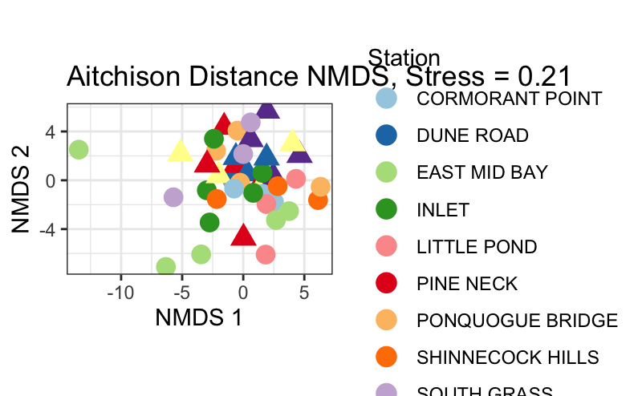

```r
## Plotting euclidean distance NMDS
nmds_aitch <- ggplot(euc_nmds_df,aes(x = MDS1, y = MDS2, color = Station, shape = Bayside)) +
  geom_point(size = 4) +
  scale_color_brewer(palette="Paired") +
  theme_bw() +
  labs(x = "NMDS 1", y = "NMDS 2", title = paste0('Aitchison Distance NMDS, Stress = ', round(euc_nmds$stress,2))) +
  coord_fixed(ratio = 1)

nmds_aitch

ggsave("figures/nmds_aitch.eps",nmds_aitch, width = 7, height = 5, units = c("in"))
```

Next try a **Jaccard NMDS**, which will represent differences in presence/absence among samples, emphasizing both abundant and rare taxa the same

```r
jac_nmds <- metaMDS(jac_dmat, k=2, autotransform=FALSE) # Run the ordination. Distance matrix was already calculated above
```

```
*** Solution reached
```

```r
jac_nmds$stress #Check the stress. Less than 0.1 is good. Less than 0.5 is better. This will be different each time, since it is iteratively finding a unique solution each time (although the should look similar)
```

```
[1] 0.1495162
```

```r
# Extract points from nmds and merge into data frame with metadata
jac_nmds_df <- data.frame(jac_nmds$points) %>%
  rownames_to_column(var = "SampleID")

# Merge metadata into the pcoa data table
jac_nmds_df <- left_join(jac_nmds_df, metadata, by = "SampleID")
head(jac_nmds_df)
```

|  | SampleID | MDS1 | MDS2 | Year.Trawl# | Datecode | Date | Month | Year | Bayside | Station |
| --- | --- | --- | --- | --- | --- | --- | --- | --- | --- | --- |
| 1 | T1S10 | -0.13554921 | 0.02782588 | 2020.T1 | 20200707 | 7/7/20 | 7 | 2020 | EAST | SOUTH GRASS |
| 2 | T1S11 | -0.07473205 | -0.07418318 | 2020.T1 | 20200707 | 7/7/20 | 7 | 2020 | EAST | LITTLE POND |
| 3 | T1S1 | -0.21647460 | 0.17006265 | 2020.T1 | 20200707 | 7/7/20 | 7 | 2020 | WEST | PINE NECK |
| 4 | T1S3 | -0.13454182 | 0.12984869 | 2020.T1 | 20200707 | 7/7/20 | 7 | 2020 | WEST | DUNE ROAD |
| 5 | T1S5 | -0.01320915 | 0.22772365 | 2020.T1 | 20200707 | 7/7/20 | 7 | 2020 | EAST | PONQUOGUE BRIDGE |
| 6 | T1S6 | 0.41875931 | 0.06944360 | 2020.T1 | 20200707 | 7/7/20 | 7 | 2020 | EAST | INLET |

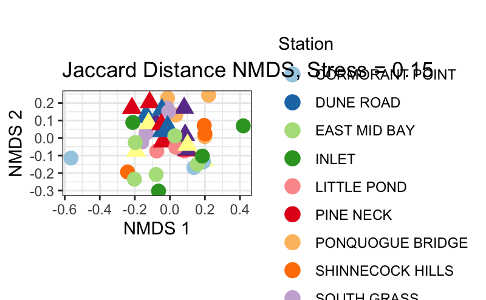

```r
## Plotting euclidean distance NMDS
nmds_jaccard <- ggplot(jac_nmds_df,aes(x = MDS1, y = MDS2, color = Station, shape = Bayside)) +
  geom_point(size = 4) +
  scale_color_brewer(palette="Paired") +
  theme_bw() +
  labs(x = "NMDS 1", y = "NMDS 2", title = paste0('Jaccard Distance NMDS, Stress = ', round(jac_nmds$stress,2))) +
  coord_fixed(ratio = 1)

nmds_jaccard

ggsave("figures/nmds_jaccard.eps",nmds_jaccard, width = 7, height = 5, units = c("in"))
```

This is still a relatively high stress (>0.1) so should be interpreted with caution. Similar to Aitchison-distance nMDS but there is a little more separation of East vs West on NMDS 2 axis.

Next try a **Bray-Curis NMDS**, which will represent differences in presence/absence among samples *and* relative abundance, thus emphasizing impacts of highly abundant taxa.

```r
bray_nmds <- metaMDS(bray_dmat, k=2, autotransform=FALSE) # Run the ordination. Distance matrix was already calculated above
```

```
*** No convergence -- monoMDS stopping criteria:
     1: no. of iterations >= maxit
    19: stress ratio > sratmax
```

```r
bray_nmds$stress #Check the stress. Less than 0.1 is good. Less than 0.5 is better. This will be different each time, since it is iteratively finding a unique solution each time (although the should look similar)
```

```
[1] 0.1496489
```

```r
# Extract points from nmds and merge into data frame with metadata
bray_nmds_df <- data.frame(bray_nmds$points) %>%
  rownames_to_column(var = "SampleID")

# Merge metadata into the pcoa data table
bray_nmds_df <- left_join(bray_nmds_df, metadata, by = "SampleID")
head(bray_nmds_df)
```

|  | SampleID | MDS1 | MDS2 | Year.Trawl# | Datecode | Date | Month | Year | Bayside | Station |
| --- | --- | --- | --- | --- | --- | --- | --- | --- | --- | --- |
| 1 | T1S10 | -0.137989648 | 0.02631204 | 2020.T1 | 20200707 | 7/7/20 | 7 | 2020 | EAST | SOUTH GRASS |
| 2 | T1S11 | -0.074997865 | -0.07425043 | 2020.T1 | 20200707 | 7/7/20 | 7 | 2020 | EAST | LITTLE POND |
| 3 | T1S1 | -0.125018971 | 0.23971219 | 2020.T1 | 20200707 | 7/7/20 | 7 | 2020 | WEST | PINE NECK |
| 4 | T1S3 | -0.142763116 | 0.11992163 | 2020.T1 | 20200707 | 7/7/20 | 7 | 2020 | WEST | DUNE ROAD |
| 5 | T1S5 | -0.007407603 | 0.22329662 | 2020.T1 | 20200707 | 7/7/20 | 7 | 2020 | EAST | PONQUOGUE BRIDGE |
| 6 | T1S6 | 0.418467796 | 0.06942688 | 2020.T1 | 20200707 | 7/7/20 | 7 | 2020 | EAST | INLET |

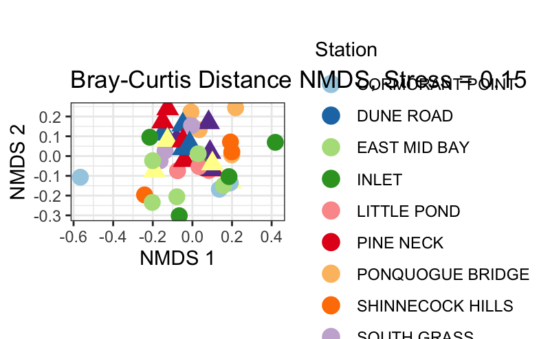

```r
## Plotting euclidean distance NMDS
nmds_bray <- ggplot(bray_nmds_df,aes(x = MDS1, y = MDS2, color = Station, shape = Bayside)) +
  geom_point(size = 4) +
  scale_color_brewer(palette="Paired") +
  theme_bw() +
  labs(x = "NMDS 1", y = "NMDS 2", title = paste0('Bray-Curtis Distance NMDS, Stress = ', round(bray_nmds$stress,2))) +
  coord_fixed(ratio = 1)

nmds_bray

ggsave("figures/nmds_bray.eps",nmds_bray, width = 7, height = 5, units = c("in"))
```

Very similar to Jaccard results. High-ish stress (0.15)

### eDNA Ordinations Summary

The ordination that explained the most variance in the eDNA dataset was the PCoA on the Bray-Curtis dissimilarity matri after Hellinger transformation. This is similar to the approach presented in [Lacoursière‐Roussel et al. 2018](https://onlinelibrary.wiley.com/doi/abs/10.1002/ece3.4213).

Next: fit environmental vectors to this ordination to see which can be possibly explain some of the variation among samples and among species.

NOTE- see this [discussion](https://stats.stackexchange.com/questions/305965/can-i-use-the-clr-centered-log-ratio-transformation-to-prepare-data-for-pca) and this [paper](https://link.springer.com/article/10.1007/s11004-008-9196-y) on why CCA should not be used with CLR-transformed compositional data to explore correlations.

## PCoA with Environmental Variables

Import environmental data from each station/ date # STOPPED HERE